# Identify Customer Segments for Mail-order Sales company

### Online affinity

- 0: none
- 1: low
- 2: middle
- 3: high
- 4: very high
- 5: highest

Histogram shows individuals with little online affinity

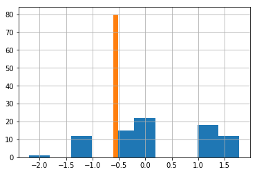

```python
cluster2['ONLINE_AFFINITAET'].head(80).hist()
cluster3['ONLINE_AFFINITAET'].head(80).hist()
```

#### HOUSEHOLD

- 1 Wealthy
- 2 Prosporous
- 3 Comfortable
- 4 Less Affluent
- 5 Poor

Bar chart below shows it is popular amongst Wealthy and Prosporous Households.

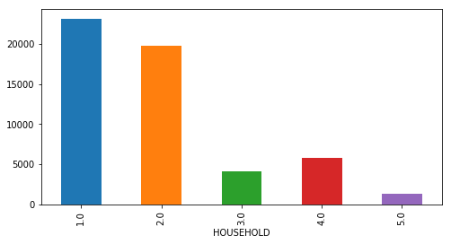

```python
cluster2.groupby('HOUSEHOLD')['HOUSEHOLD'].count().plot.bar(figsize=(8,4));
plt.show()
# cluster3['HOUSEHOLD'] - No data avalaible, Lets look at the third most popular cluster then
#cluster3.groupby('HOUSEHOLD')['HOUSEHOLD'].count().plot.bar(figsize=(8,4));
#plt.show()
```

#### GENERATION

- 1 40s
- 2 50s
- 3 60s
- 4 70s
- 5 80s
- 6 90s

Bar chart below shows mail would be popular amongst the older generation starting from the 50s and slowly declining till the 70s untill it eventually tapers off as it reaches the millinials. It is very probable considering that the new generation prefers to use electronic mail etc for communication.

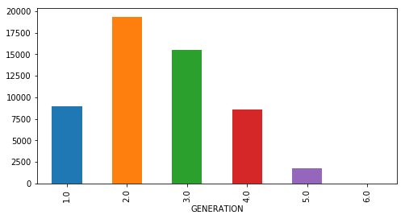

```python
cluster2.groupby('GENERATION')['GENERATION'].count().plot.bar(figsize=(8,4));
plt.show()
#cluster3.groupby('GENERATION')['GENERATION'].count().plot.bar(figsize=(8,4));
#plt.show()
```

LIFESTYLE

- 1 Pre-Family Couples & Singles
- 2 Young Couples With Children
- 3 Families With School Age Children
- 4 Older Families & Mature Couples
- 5 Elders In Retirement

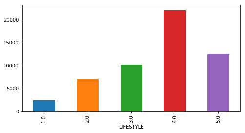

```python
cluster2.groupby('LIFESTYLE')['LIFESTYLE'].count().plot.bar(figsize=(8,4));
plt.show()
```

#### Financial Topology

- 1: very high
- 2: high
- 3: average
- 4: low
- 5: very low

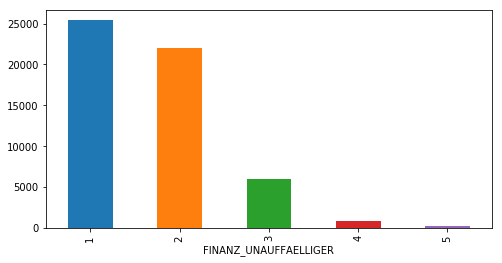

```python
cluster2.groupby('FINANZ_UNAUFFAELLIGER')['FINANZ_UNAUFFAELLIGER'].count().plot.bar(figsize=(8,4));
plt.show()
```

#### Personality - materialistic

- 1: highest affinity
- 2: very high affinity
- 3: high affinity
- 4: average affinity
- 5: low affinity
- 6: very low affinity
- 7: lowest affinity
- 9: unknown

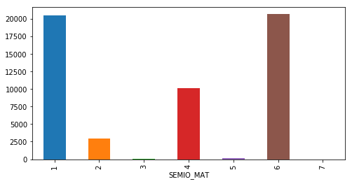

```python
cluster2.groupby('SEMIO_MAT')['SEMIO_MAT'].count().plot.bar(figsize=(8,4));
plt.show()
```

```python
#cluster2.info()
```

### Cluster 10 - Observation

Note that cluster 10 has features that would under favorable circumstances make it an ideal canditate however the features which presumebly make them an unlikely choice seems to be there

- High Online Affinity
- Very low affinity to materistic things and wants
- An average financial status

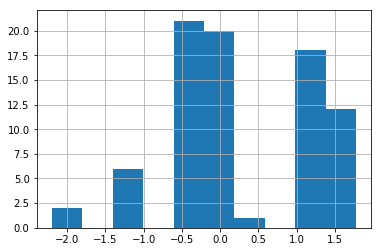

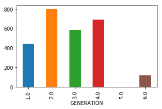

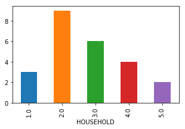

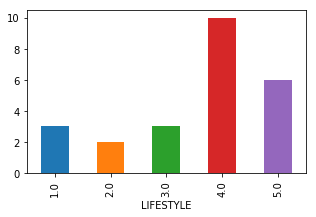

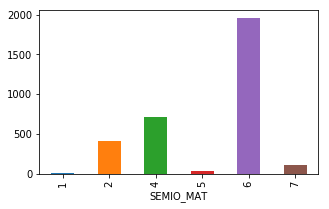

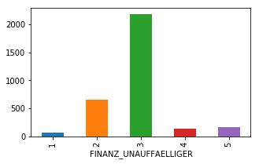

```python
cluster10['ONLINE_AFFINITAET'].head(80).hist()
plt.show()
cluster10.groupby('GENERATION')['GENERATION'].count().plot.bar(figsize=(5,3));
plt.show()
cluster10.groupby('HOUSEHOLD')['HOUSEHOLD'].count().plot.bar(figsize=(5,3));
plt.show()
cluster10.groupby('LIFESTYLE')['LIFESTYLE'].count().plot.bar(figsize=(5,3));
plt.show()
cluster10.groupby('SEMIO_MAT')['SEMIO_MAT'].count().plot.bar(figsize=(5,3));
plt.show()
cluster10.groupby('FINANZ_UNAUFFAELLIGER')['FINANZ_UNAUFFAELLIGER'].count().plot.bar(figsize=(5,3));
plt.show()
```

### Cluster 1 - Observation

```
Note that cluster 1 consists of the younger generation
```

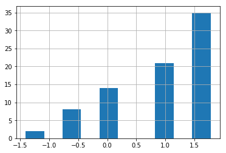

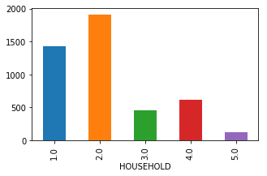

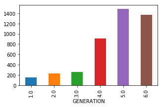

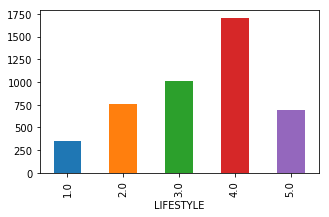

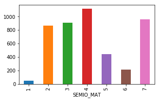

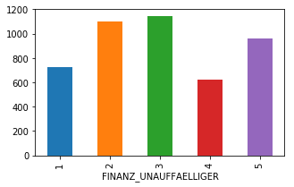

```python
print('Note that cluster 1 consists of the younger generation')
cluster1['ONLINE_AFFINITAET'].head(80).hist()
plt.show()
cluster1.groupby('HOUSEHOLD')['HOUSEHOLD'].count().plot.bar(figsize=(5,3));
plt.show()
cluster1.groupby('GENERATION')['GENERATION'].count().plot.bar(figsize=(5,3));
plt.show()
cluster1.groupby('LIFESTYLE')['LIFESTYLE'].count().plot.bar(figsize=(5,3));
plt.show()
cluster1.groupby('SEMIO_MAT')['SEMIO_MAT'].count().plot.bar(figsize=(5,3));
plt.show()
cluster1.groupby('FINANZ_UNAUFFAELLIGER')['FINANZ_UNAUFFAELLIGER'].count().plot.bar(figsize=(5,3));
plt.show()
```

### Discussion 3.3: Compare Customer Data to Demographics Data

- No need for seperation of values as the analysis performed in step 1.1.3 showed that after seperating the feature shape/dimension didn't have significant change on the bulk of the data therefore doesn't need to be treated as an additional cluster.
- Popular and unpopular segments/clustors and their features have been categoricaly explained

In summary, the bank ought to look for customers who:

[output not shown]

They should avoid:

```
1. The younger generation
2. Individals who have good access to internet(online affinity)
3. Low Financial Topology
4. Young couples/New marrages
```